# 1. Descripción de la estación

La estación pluviométrica COPIAPO, administrada por DGA, se localiza en la Región DE ATACAMA, a una latitud de -27.36° y longitud -70.34°, con una elevación aproximada de 385 m s.n.m.. La estación registra la variable precipitación diaria (mm/día) y cuenta con una serie de datos que se extiende desde el 1971-01-01 hasta el 2025-05-31 , totalizando 19875 días en el período de análisis. De estos, 18643 días presentan registros válidos, lo que corresponde a una cobertura del 93.8%, sin detección de valores atípicos.

# 2. Descripción metodológica de las métricas de precipitación

La caracterización de la variabilidad, intensidad y extremos de la precipitación se realizó a partir de la serie diaria de precipitación, calculando métricas anuales por año hidrológico (abril–marzo). Las métricas empleadas corresponden a índices ampliamente utilizados en climatología e hidrología, en particular aquellos propuestos por el Expert Team on Climate Change Detection and Indices (ETCCDI).

### Precipitación total anual en días húmedos (PRCPTOT)

La métrica **PRCPTOT** corresponde a la suma anual de la precipitación diaria registrada en días húmedos, definidos como aquellos con precipitación estrictamente mayor a 0 mm. Este indicador permite cuantificar la cantidad total de agua precipitada en un año hidrológico, excluyendo los días secos.

Matemáticamente, se define como:

$$PRCPTOT_j = \sum_{i=1}^{N_j} RR_{ij}, \quad \text{con } RR_{ij} > 0$$

donde $RR_{ij}$ es la precipitación diaria del día $i$ en el año hidrológico $j$, y $N_j$ corresponde al número total de días del año.

### Índice de intensidad diaria simple (SDII)

El **SDII (Simple Daily Intensity Index)** representa la intensidad media de la precipitación durante los días húmedos de un año hidrológico. Se calcula como el cociente entre la precipitación total anual en días húmedos y el número de días húmedos del año.

Se modifico para los años con registro de precipitación 0, para estos se les asigna un $SDII = 0$
$$SDII_j = \frac{\sum RR_{ij}}{N_{wet,j}}, \quad \text{con } RR_{ij} >
0$$

donde $N_{wet,j}$ es el número de días húmedos del año hidrológico $j$. Valores elevados de SDII indican una mayor concentración de la precipitación en eventos intensos.

### Precipitación máxima en 1 día (Rx1day)

La métrica **Rx1day** corresponde al mayor monto de precipitación diaria registrado dentro de un año hidrológico y es un indicador directo de eventos extremos de corta duración.

$$Rx1day_j = \max(RR_{ij})$$

### Precipitación máxima en 5 días consecutivos (Rx5day)

La métrica **Rx5day** representa el máximo acumulado de precipitación en cualquier período móvil de cinco días consecutivos dentro de un año hidrológico. Para su cálculo se utiliza una suma móvil de cinco días.

$$Rx5day_j = \max \left( \sum_{k=i}^{i+4} RR_{kj} \right)$$

Este índice es relevante para evaluar eventos persistentes asociados a crecidas y saturación del suelo.

### Número de días con precipitación mayor o igual a 10 mm (R10mm)

El índice **R10mm** corresponde al número de días en un año hidrológico en los que la precipitación diaria es igual o superior a 10 mm, y permite evaluar la frecuencia de eventos de precipitación moderada a intensa.

$$R10mm_j = \sum_{i=1}^{N_j} I(RR_{ij} \ge 10)$$

donde $I(\cdot)$ es una función indicadora que toma valor 1 cuando la condición se cumple y 0 en caso contrario.

### Número de días con precipitación mayor o igual a 20 mm (R20mm)

El índice **R20mm** contabiliza el número de días por año hidrológico con precipitación diaria igual o superior a 20 mm, asociado a eventos intensos.

$$R20mm_j = \sum_{i=1}^{N_j} I(RR_{ij} \ge 20)$$

### Máxima racha de días secos consecutivos (CDD)

La métrica **CDD (Consecutive Dry Days)** corresponde al mayor número de días secos consecutivos dentro de un año hidrológico, considerando como día seco aquel con precipitación igual a 0 mm.

$$CDD_j = \max(L_{dry})$$

donde $L_{dry}$ representa la longitud de cada racha consecutiva de días con $RR_{ij} = 0$.

### Máxima racha de días húmedos consecutivos (CWD)

La métrica **CWD (Consecutive Wet Days)** corresponde al mayor número de días húmedos consecutivos dentro de un año hidrológico, definiendo como día húmedo aquel con precipitación mayor a 0 mm.

$$CWD_j = \max(L_{wet})$$

donde $L_{wet}$ representa la longitud de cada racha consecutiva de días con $RR_{ij} > 0$.

### Precipitación anual sobre el percentil 95 (R95pTOT)

La métrica **R95pTOT** corresponde a la suma anual de la precipitación diaria asociada a eventos extremos moderados, definidos como aquellos días cuya precipitación supera el percentil 95 ($P_{95}$) de la distribución de precipitación diaria positiva del período de referencia.

$$R95pTOT_j = \sum RR_{ij}, \quad \text{con } RR_{ij} > P_{95}$$

### Precipitación anual sobre el percentil 99 (R99pTOT)

La métrica **R99pTOT** representa la suma anual de la precipitación diaria correspondiente a eventos extremos severos, definidos como aquellos días con precipitación superior al percentil 99 ($P_{99}$) de la distribución de precipitación diaria positiva del período de referencia.

$$R99pTOT_j = \sum RR_{ij}, \quad \text{con } RR_{ij} > P_{99}$$

# 3.Resultados

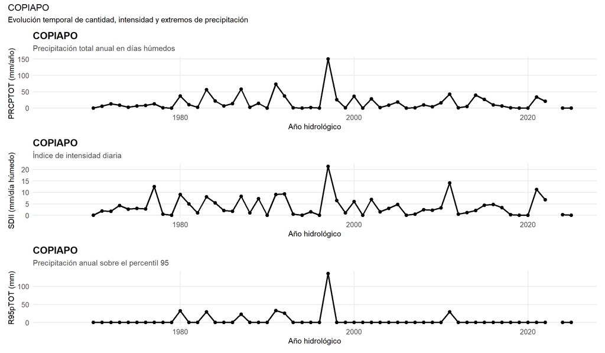

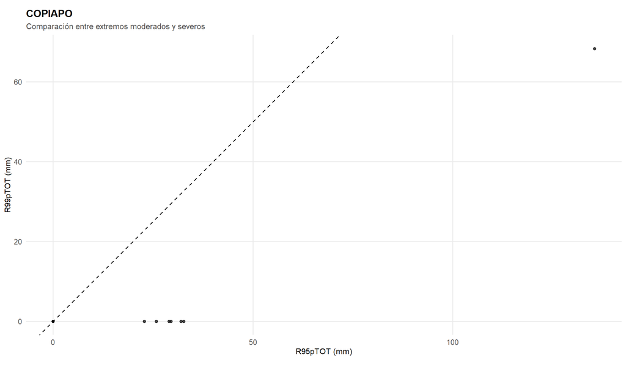

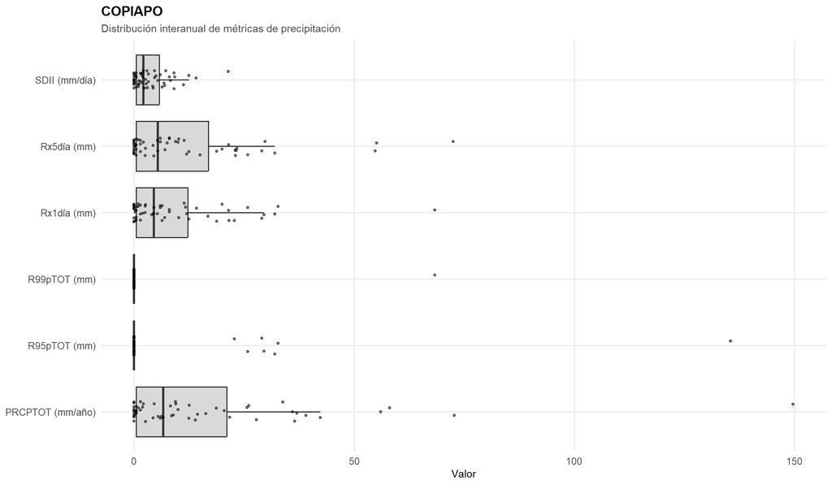

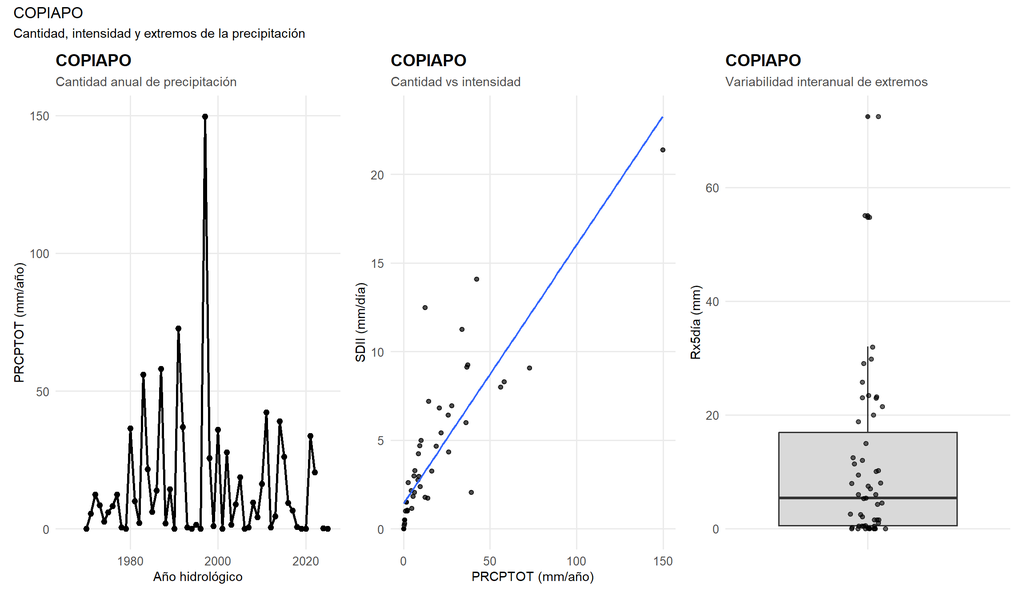